# Tidybiology Final Project

Samyuktha Suresh

September 30, 2022

## Import data

As part of my PhD thesis, I am analysing some mouse retinal datasets that contain samples from control and injured retina from different age groups. I initially used [Seurat](https://satijalab.org/seurat/index.html) a popular scRNA analysis package. With Seurat you can add and edit metadata information for your samples.This metadata was extracted as a dataframe. Some columns were renamed to make the dataset more user friendly.

## A `glimpse` of the dataset

The dataframe contains important information pertaining to each unique cell that was sequenced.

```
## Rows: 51,582
## Columns: 6
## $ cells                <chr> "3NI_AAACCCAAGGATAATC-1", "3NI_AAACCCACAATAGTAG-1~
## $ orig.ident           <fct> NI_3, NI_3, NI_3, NI_3, NI_3, NI_3, NI_3, NI_3, N~
## $ No_of_mRNA_detected  <int> 1713, 2636, 578, 661, 602, 718, 5256, 3434, 690, ~
## $ No_of_genes_detected <int> 925, 1408, 421, 458, 432, 478, 2539, 1804, 457, 1~
## $ log10GenesPerUMI     <dbl> 2.456434, 2.614457, 2.183070, 2.210585, 2.191502,~
## $ percent.mt           <dbl> 4.1447752, 2.0864947, 0.3460208, 0.7564297, 0.166~
```

## Exploratory data analysis

I’d like to explore the relationship between the number of mRNA molecules detected vs the number of genes detected.

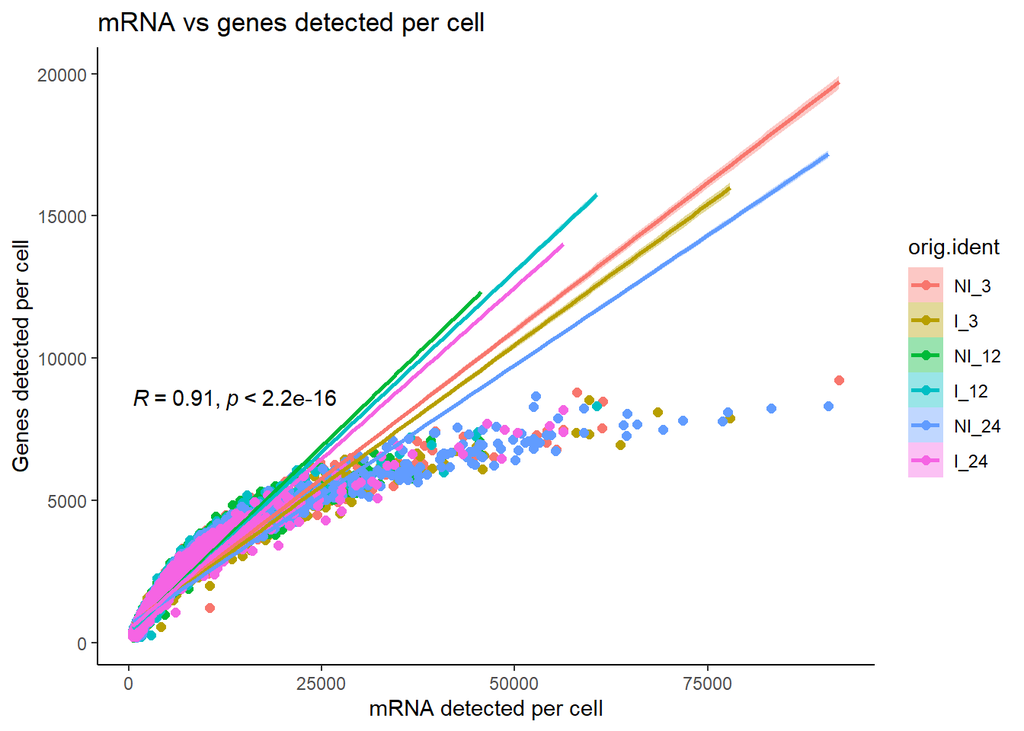

## Mitochondrial quality control metrics graph

One important step before starting scRNA analysis is to understand how some parameters look like in your dataset so you can set appropriate quality control filters to further clean up your data. Below you can see some such graphs.

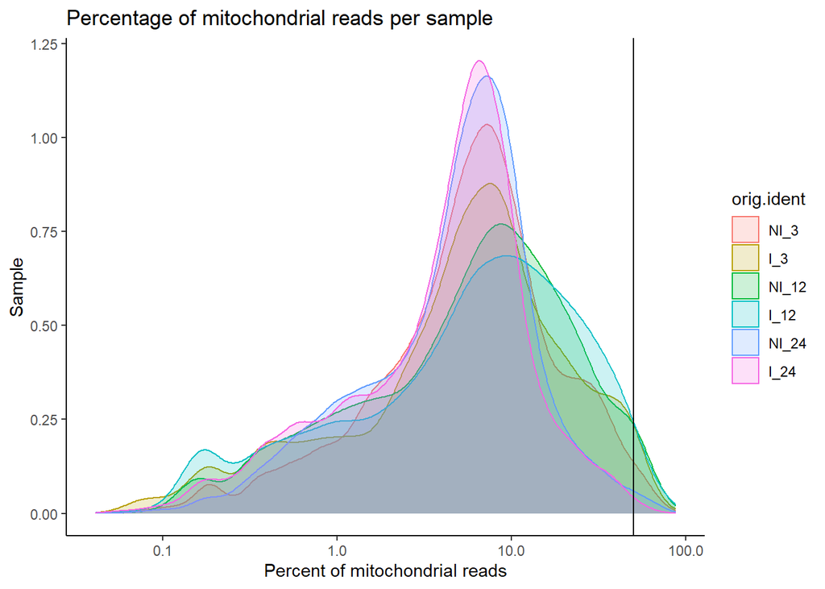

## Conclusions

Most of the mitochondrial reads per cell falls within 50%. This is higher than what is usually seen, and from literature searches suggests that retinal datasets have high percentage of mitochondrial reads.

## Prioritized follow-up studies

I would like to do some group-wise analysis of quality control parameters such as genes detected per cell across conditions like age and injury.

## Acknolwedgements

Thanks to the Seurat package makers, Harvard Bioinfo core github page and Google in helping me putter around in R. Shout out to our instructor Prof Matthew, our classmates, and my friend Swathi, with whom learning in this class has been fun!